# Cov19: Long-final evaluation

```python
import os
import ast
import sys
import shutil
import joblib
import functools
import statistics
import pandas as pd
import numpy as np
import seaborn as sns
import matplotlib.pyplot as plt
from pathlib import Path
from pprint import pformat, pprint
from helpers import _build_summary_data, plot_missing_values_per_group, ModelEvaluation
from misc.df_plotter.mv_plotter import MissingValuePlotter
from misc.df_plotter.box_plotter import BoxPlotter
from sklearn.model_selection import train_test_split
from sklearn.linear_model import LogisticRegression
from sklearn.neighbors import KNeighborsClassifier, KNeighborsRegressor
from sklearn.pipeline import Pipeline
from sklearn.compose import ColumnTransformer
from sklearn.impute import SimpleImputer
from sklearn.preprocessing import MinMaxScaler, OneHotEncoder
from sklearn.preprocessing import StandardScaler
from sklearn.preprocessing import OrdinalEncoder, FunctionTransformer
from sklearn.model_selection import GridSearchCV, KFold
from sklearn.ensemble import RandomForestClassifier, AdaBoostClassifier, BaggingClassifier, GradientBoostingClassifier
from sklearn.svm import LinearSVC, NuSVC, SVC
from sklearn.tree import DecisionTreeClassifier, ExtraTreeClassifier
from sklearn.impute import KNNImputer
from sklearn.feature_selection import VarianceThreshold, SelectKBest
from mlxtend.feature_selection import SequentialFeatureSelector as SFS
from mlxtend.plotting import plot_sequential_feature_selection as plot_sfs
from sklearn.metrics import accuracy_score, classification_report
from sklearn.utils import estimator_html_repr
from IPython.core.display import display, HTML
from IPython.display import Markdown as md
from IPython.display import Image
from sklearn.metrics import confusion_matrix, plot_confusion_matrix, classification_report, plot_roc_curve, plot_precision_recall_curve
from plotly.offline import download_plotlyjs, init_notebook_mode, plot, iplot
init_notebook_mode(connected=True)
```

```python
# REMARK: change parameters of this cell and the script/notebook will run for either longitudinal
# or base evaluation, but markdown text will mostly not be influenced. So markdown cells have
# to be adjusted by hand in every script!

study_type = 'long' # 'base', 'long'
target = 'final_result'  # target feature as string
target_mapping = {'survived': 1, 'died': 0}
working_file = "working_file_long_2021-03-22"  # name of working file (without ending) as string
chosen_model = None # if None best model (mean test accuracy) is taken
re_calculate = False  # time consuming calculations will not be done again if re_calculate = False and file exists in folder
no_features = 15 # number of features for SFS (Feature Importance)
test_size = 0.25  # chosen size of analyzed test set
```

This notebook shows the methodical way of analyzing the **longitudinal data** of **COV19** (died vs. survived)

1. run **'train_test_split_analysis.py'** with repeated randomized train-test-splits with different split-sizes -> **evaluate the optimal fraction to split into train- and test data** .
2. selecting 'optimal' train-test-split-size-fraction and **getting best model from all supported model types** (LogisticRegression, KNeighborsClassifier, RandomForestClassifier, AdaBoostClassifier, BaggingClassifier, GradientBoostingClassifier, SVC). **Best model = reaching best mean test-accuracy-score (on unseen data)**
3. With this model and its best hyperparameters **retrain all data** and analyze results with its **FeatureImportance**

## 1. train_test_split_analysis

In this section the behaviour between train-data-size and test-data-size is analyzed. Goal ist to get an optimal fraction the reach stable and valid results. An optimal fraction is reached if variance in results on train- and test-data is relativly low. Normally many train-data and few test-data leeds to a low variance in train but a high variance in test-results and visa verse. Somewhere between should be an optimum. This fraction is taken for further analysis!

```python
if study_type == 'long':
    data = pd.read_pickle(f"{working_file}.pkl")
else:
    data = pd.read_pickle(f"{working_file}_adjusted.pkl")
```

```python
fig = MissingValuePlotter(df=data).get_plot()
fig.write_html(f"MissingValuePlotter.html")
fig.show()
```

[interactive chart not shown]

```python
data_summary = _build_summary_data(data, target)
fig = plot_missing_values_per_group(data_summary, target)
fig.write_html(f"mv_per_group_before_transformation.html")
fig.show()
```

[interactive chart not shown]

From train-test-split-analysis the next 2 plots have been generated:

- data-file have been analyzed with 15 different randomized splits into train- and testdata (random_states: 1211,2341,4351,5641,1521,6541,8961,9851,7471,8681,9011,4321,9801,1921,8561) and different test-sizes (**test_sizes: 0.1, 0.15, 0.2, 0.25, 0.3, 0.35**)
- the results of this simulation has been plotted per algorithm (**LogisticRegression, KNeighborsClassifier, RandomForestClassifier, AdaBoostClassifier, BaggingClassifier, GradientBoostingClassifier, SVC**)

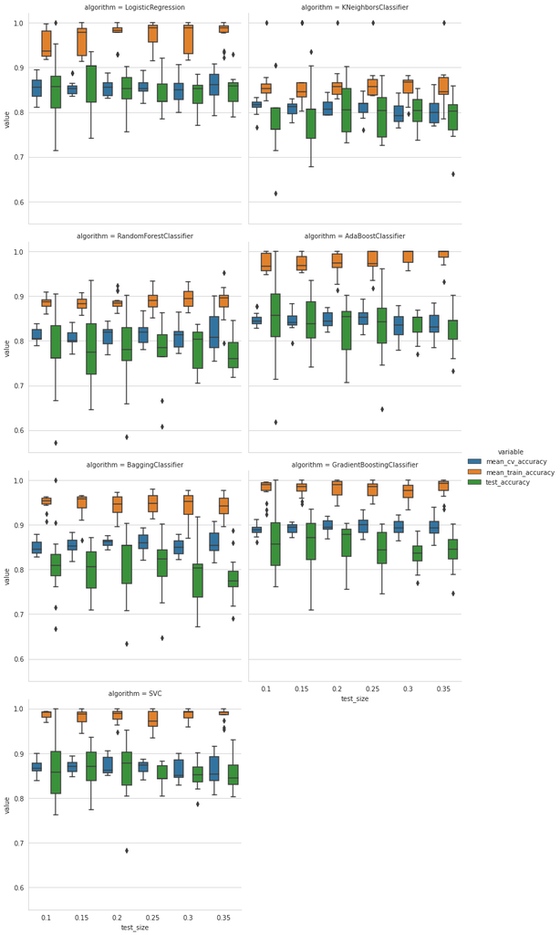

```python
try:
    sim_data = pd.read_csv(f"train_test_split_simulation.csv", index_col=0)
except FileNotFoundError:
    raise Exception(f"File not found!")

data_mod = sim_data.melt(id_vars=['algorithm', 'test_size', 'random_state'],
                     value_vars=['mean_cv_accuracy', 'mean_train_accuracy', 'test_accuracy'])
# build plot
sns.set_style("whitegrid")
sns.catplot(data=data_mod, x='test_size', y='value', col='algorithm', hue='variable', kind='box', col_wrap=2)
plt.savefig(f"train_test_analysis.png")
```

These plots show the estimated behaviour. With low test-sizes (0.1) the variance in test_accuracy is high. This variance is getting lower if the test_size is increased. From visual sight an optimum could be around a **test-size of 0.25**. At this point variance of train- and test-accuracy seems to be relatively low.

## 2. getting best model from all suported model types

In a second step the best model of all supported models and hyperparameters is selected. The best model is this one reaching the best mean test-accuracy-score (accuracy score on unseen data). After catching the **optimal train-test-split-size of 0.25** only these results will be considered on next steps of this analysis!

Output of former analysis have been two .csv file with all best models (hyperparameters) per algorithm and train-test-split/random_state.

```python
pd.DataFrame(sim_data)
```

|  | algorithm | simulation | best_params | mean_cv_accuracy | cv_std | mean_train_accuracy | train_std | test_accuracy | test_size | random_state |
| --- | --- | --- | --- | --- | --- | --- | --- | --- | --- | --- |
| 0 | LogisticRegression | 0 | {'estimator__C': 1, 'estimator__penalty': 'l2'... | 0.872222 | 0.051520 | 0.979167 | 0.007607 | 0.857143 | 0.10 | 1211 |
| 1 | KNeighborsClassifier | 0 | {'estimator__n_neighbors': 5, 'estimator__weig... | 0.816667 | 0.067128 | 0.848611 | 0.013466 | 0.761905 | 0.10 | 1211 |
| 2 | RandomForestClassifier | 0 | {'estimator__max_depth': 3, 'estimator__min_sa... | 0.805556 | 0.030429 | 0.909722 | 0.019145 | 0.714286 | 0.10 | 1211 |
| 3 | AdaBoostClassifier | 0 | {'estimator__base_estimator': DecisionTreeClas... | 0.877778 | 0.028328 | 0.990278 | 0.007082 | 0.809524 | 0.10 | 1211 |
| 4 | BaggingClassifier | 0 | {'estimator__base_estimator': DecisionTreeClas... | 0.861111 | 0.063343 | 0.962500 | 0.011283 | 0.809524 | 0.10 | 1211 |
| ... | ... | ... | ... | ... | ... | ... | ... | ... | ... | ... |
| 625 | RandomForestClassifier | 89 | {'estimator__max_depth': 3, 'estimator__min_sa... | 0.861538 | 0.052172 | 0.898077 | 0.021586 | 0.845070 | 0.35 | 8561 |
| 626 | AdaBoostClassifier | 89 | {'estimator__base_estimator': DecisionTreeClas... | 0.846154 | 0.024325 | 0.969231 | 0.012756 | 0.845070 | 0.35 | 8561 |
| 627 | BaggingClassifier | 89 | {'estimator__base_estimator': DecisionTreeClas... | 0.884615 | 0.087706 | 0.973077 | 0.003846 | 0.802817 | 0.35 | 8561 |
| 628 | GradientBoostingClassifier | 89 | {'estimator__learning_rate': 0.1, 'estimator__... | 0.923077 | 0.054393 | 0.982692 | 0.012756 | 0.887324 | 0.35 | 8561 |
| 629 | SVC | 89 | {'estimator__C': 5, 'estimator__kernel': 'rbf'... | 0.884615 | 0.048650 | 0.988462 | 0.003846 | 0.845070 | 0.35 | 8561 |

630 rows × 10 columns

From this tables only **test_size=0.25** will be taken for further analysis: The best model overall is the model with the best mean-test-accuracy (on test-size=0.25). It's best hyperparameters are detected in a majority-vote

```python
size_test_data = 0.25

def build_best_param_from_str(params):
    best_param = {}
    param_str = params.index[0]
    param_str = param_str[1:-1]
    param_str_list = str.split(param_str, ',')
    for item in param_str_list:
        item_list = str.split(item, ':')
        for ch in ['"', '\\', "'", " "]:
            item_list[0] = item_list[0].replace(ch, '')
        best_param.update({item_list[0]: eval(item_list[1])})
    return best_param

for i, sd in enumerate([sim_data]):
    data_red = sd[sd['test_size'] == size_test_data]  # optimum between variance in train- and test-score (watch plot)
    best_algorithms = data_red.groupby("algorithm").mean().sort_values(by=['test_accuracy', 'mean_cv_accuracy'], ascending=False)

    if chosen_model is None:
        best_algorithm = best_algorithms.index[0]
        idx = 0
    else:
        best_algorithm = chosen_model
        idx = best_algorithms.index.get_loc(chosen_model)

    best_params = data_red[data_red['algorithm'] == best_algorithm].groupby('best_params').count().sort_values(by="algorithm", ascending=False)
    # best_param = ast.literal_eval(best_params.index[idx])
    best_param = build_best_param_from_str(best_params)

    # performances of best algorithm
    stats = data_red.loc[:, ['mean_cv_accuracy', 'mean_train_accuracy', 'test_accuracy']][
        data_red['algorithm'] == best_algorithm].agg(['mean', 'std'])

    results = {best_algorithm: best_param, 'statistics': stats}
    joblib.dump(results, f"best_model.joblib")
    print(f"{best_algorithm}\n")
    print(f"{best_param}\n")
    print(f"{stats}")
```

```
SVC

{'estimator__C': 5, 'estimator__kernel': 'rbf', 'prep__cat_pipeline__imputer_cat__n_neighbors': 1, 'prep__num_pipeline__imputer_num__n_neighbors': 1}

      mean_cv_accuracy  mean_train_accuracy  test_accuracy
mean          0.870222             0.975556       0.849673
std           0.014224             0.020622       0.026376
```

## 3. Model evaluation and Feature Importance

In former chapters no word about the model pipelines and it's tuning parameters have been lost. These will be shown in this section. Will will analyze data and it's predictions with best evaluated model in section 2.

### EDA

```python
if study_type == 'long':
    data = pd.read_pickle(f"{working_file}.pkl")
else:
    data = pd.read_pickle(f"{working_file}_adjusted.pkl")
data.head(5)
```

|  | final_result | sex | age | albumin_1 | albumin_2 | albumin_3 | albumin_4 | crp_1 | crp_2 | crp_3 | ... | basoQlymphocytes_2 | basoQlymphocytes_3 | basoQlymphocytes_4 | basoQlymphocytes_5 | basoQlymphocytes_6 | basoQlymphocytes_7 | basoQlymphocytes_8 | basoQlymphocytes_9 | basoQlymphocytes_10 | basoQlymphocytes_11 |
| --- | --- | --- | --- | --- | --- | --- | --- | --- | --- | --- | --- | --- | --- | --- | --- | --- | --- | --- | --- | --- | --- |
| 0 | died | F | 88.0 | NaN | NaN | NaN | NaN | 0.14 | 0.24 | 1.20 | ... | 0.022556 | 0.063291 | 0.114286 | 0.047619 | 0.071429 | 0.020000 | NaN | NaN | NaN | NaN |
| 1 | survived | M | 71.0 | NaN | NaN | NaN | NaN | 0.90 | 3.80 | 8.50 | ... | 0.022556 | 0.025424 | NaN | NaN | NaN | NaN | NaN | NaN | NaN | NaN |
| 2 | died | F | 75.0 | 3.2 | NaN | NaN | NaN | 10.35 | 9.81 | 13.56 | ... | 0.017857 | NaN | NaN | NaN | NaN | NaN | NaN | NaN | NaN | NaN |
| 3 | died | M | 80.0 | NaN | NaN | NaN | NaN | 8.55 | 8.87 | 14.60 | ... | 0.014388 | 0.014493 | 0.009259 | 0.025000 | 0.018519 | NaN | NaN | NaN | NaN | NaN |
| 4 | survived | F | 86.0 | NaN | NaN | NaN | NaN | 11.75 | 5.91 | 3.28 | ... | 0.013793 | 0.033898 | 0.018987 | 0.009524 | 0.019324 | 0.015748 | NaN | NaN | NaN | NaN |

5 rows × 331 columns

```python
data.describe().T
```

|  | count | mean | std | min | 25% | 50% | 75% | max |
| --- | --- | --- | --- | --- | --- | --- | --- | --- |
| age | 201.0 | 67.691542 | 17.501554 | 22.000000 | 57.000000 | 70.000000 | 80.000000 | 96.000000 |
| albumin_1 | 28.0 | 3.025000 | 0.615615 | 1.800000 | 2.700000 | 3.150000 | 3.225000 | 4.500000 |
| albumin_2 | 11.0 | 2.745455 | 0.733980 | 1.900000 | 2.350000 | 2.500000 | 3.050000 | 4.300000 |
| albumin_3 | 3.0 | 3.000000 | 0.984886 | 1.900000 | 2.600000 | 3.300000 | 3.550000 | 3.800000 |
| albumin_4 | 1.0 | 2.800000 | NaN | 2.800000 | 2.800000 | 2.800000 | 2.800000 | 2.800000 |
| ... | ... | ... | ... | ... | ... | ... | ... | ... |
| basoQlymphocytes_7 | 16.0 | 0.057371 | 0.085875 | 0.011050 | 0.016943 | 0.032537 | 0.053105 | 0.361111 |
| basoQlymphocytes_8 | 6.0 | 0.029425 | 0.019775 | 0.007752 | 0.016884 | 0.026724 | 0.035371 | 0.063492 |
| basoQlymphocytes_9 | 1.0 | 0.021858 | NaN | 0.021858 | 0.021858 | 0.021858 | 0.021858 | 0.021858 |
| basoQlymphocytes_10 | 1.0 | 0.040698 | NaN | 0.040698 | 0.040698 | 0.040698 | 0.040698 | 0.040698 |
| basoQlymphocytes_11 | 0.0 | NaN | NaN | NaN | NaN | NaN | NaN | NaN |

300 rows × 8 columns

```python
data.info()
```

```
<class 'pandas.core.frame.DataFrame'>
Int64Index: 201 entries, 0 to 200
Columns: 331 entries, final_result to basoQlymphocytes_11
dtypes: category(31), float64(300)
memory usage: 481.7 KB
```

```python
if study_type == 'base':
    if not os.path.isfile('pairplot.png'):
        plt.figure(figsize=(15,8))
        fig = sns.pairplot(data=data, hue='group', plot_kws={'alpha':0.2})
        fig.savefig('pairplot.png')
    else:
        display(Image(filename='pairplot.png'))
```

```python
mv = data.isna().sum().sum()
frac = round((mv / (data.shape[0]*data.shape[1])) * 100, 3)
md("The data contains <b>{}</b> missing values in overall, that is a fraction of <b>{}</b>%.".format(mv, frac))
```

The data contains **44160** missing values in overall, that is a fraction of **66.375**%.

The missing value-plot is already shown in part 1 as well as the missing data per subgropup.

```python
if study_type == 'base':
    bp = BoxPlotter(df=data, features=None, split=target)
    bp.update_layout(n_cols=3, n_rows=3, style_grid={'vertical_spacing': 0.1, 'horizontal_spacing': 0.1},
                     colors={'positive': 'green', 'negative': 'red'}, style_figure={'boxpoints': 'all'})
    figs = bp.get_plot()
    for idx, item in enumerate(figs):
        item.update_layout(title_text=f"Boxplot {idx}", width=1600, height=800)
        item.show()

    bp.store(path=f'{os.getcwd()}', name=f"BoxPlotter")
```

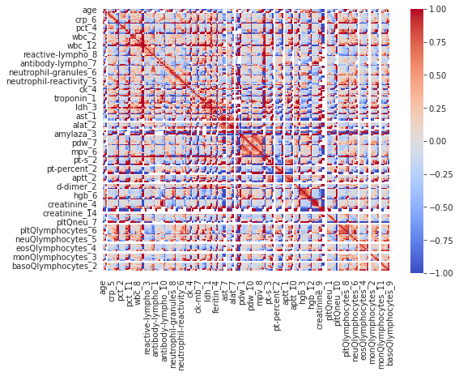

```python
plt.figure(figsize=(8,6))
sns.heatmap(data=data.corr(), cmap='coolwarm')
plt.show()
```

Next target variable has to be replaced by numeric values to calculate correlation of features to target.

```python
data_mod = data.copy()
data_mod[target] = data_mod[target].map(target_mapping)
data_mod[target] = data_mod[target].astype('float')
data_mod.corr()[target].sort_values()
```

```
pt-s_8                -1.000000
hgb_12                -1.000000
aptt_8                -0.999971
amylaza_3             -0.993399
alat_7                -0.990926
                         ...
monQlymphocytes_10          NaN
monQlymphocytes_11          NaN
basoQlymphocytes_9          NaN
basoQlymphocytes_10         NaN
basoQlymphocytes_11         NaN
Name: final_result, Length: 301, dtype: float64
```

### Machine Learning

The pipeline for the ML-workflow looks as following:

```python
pipe = joblib.load(f'pipe.joblib')
```

```python
params = joblib.load(f'params.joblib')
print(pformat(params))
```

```
([{'prep__cat_pipeline__imputer_cat__n_neighbors': [1, 3],
   'prep__num_pipeline__imputer_num__n_neighbors': [1, 3]}],
 [{'estimator': [LogisticRegression()],
   'estimator__C': [0.1, 1, 10],
   'estimator__penalty': ['l2']},
  {'estimator': [KNeighborsClassifier()],
   'estimator__n_neighbors': [3, 5, 7, 9],
   'estimator__weights': ['uniform', 'distance']},
  {'estimator': [RandomForestClassifier()],
   'estimator__max_depth': [1, 2, 3],
   'estimator__min_samples_leaf': [0.01, 0.05, 0.1],
   'estimator__min_samples_split': [0.001, 0.01, 0.1]},
  {'estimator': [AdaBoostClassifier()],
   'estimator__base_estimator': [DecisionTreeClassifier(max_depth=1)],
   'estimator__learning_rate': [0.1, 0.25, 0.5, 0.75, 1.0]},
  {'estimator': [BaggingClassifier()],
   'estimator__base_estimator': [DecisionTreeClassifier(max_depth=1),
                                 DecisionTreeClassifier(max_depth=2),
                                 DecisionTreeClassifier(max_depth=3),
                                 DecisionTreeClassifier(max_depth=4)],
   'estimator__max_features': [0.2, 0.4, 0.6, 0.8, 1.0]},
  {'estimator': [GradientBoostingClassifier()],
   'estimator__learning_rate': [0.15, 0.1, 0.05, 0.01],
   'estimator__max_depth': [1, 2],
   'estimator__max_features': ['auto', 'sqrt', 'log2'],
   'estimator__min_samples_leaf': [0.005, 0.01, 0.05, 0.1],
   'estimator__subsample': [0.8, 0.9, 1]},
  {'estimator': [SVC()],
   'estimator__C': [0.1, 0.5, 1, 5, 10],
   'estimator__kernel': ['linear', 'rbf', 'poly']}])
```

Best hyperparameters as well as the performance statistics have been evaluated in section above: These are:

```python
results = joblib.load(f"best_model.joblib")
keys = list(results.keys())
best_algorithm_name = keys[0]
print(f"Best algorithm: {best_algorithm_name}\n")
print(f"Best parameters: {results.get(keys[0])}\n")
print(f"statistics: {results.get(keys[1])}")
```

```
Best algorithm: SVC

Best parameters: {'estimator__C': 5, 'estimator__kernel': 'rbf', 'prep__cat_pipeline__imputer_cat__n_neighbors': 1, 'prep__num_pipeline__imputer_num__n_neighbors': 1}

statistics:       mean_cv_accuracy  mean_train_accuracy  test_accuracy
mean          0.870222             0.975556       0.849673
std           0.014224             0.020622       0.026376
```

The model will be build from pipeline by replacing the dummy estimator by the best estimator and update the hyperparameters in the pipe. After this the pipe can be fitted on overall data!

```python
X = data.drop([target], axis=1)
y = data[target]
y = y.map(target_mapping)  # for precision_scorer labels have to be binary with 0,1
```

```python
updated_params = results.get(keys[0])
updated_params = {key:[value] for key,value in updated_params.items()}  # values have to be defined as list
updated_pipe = pipe
updated_pipe.steps.pop(-1)
updated_pipe.steps.append(('estimator', eval(f"{keys[0]}()")))  # adding () behind best model name and evaluate -> function
```

```python
kfold = KFold(n_splits=5, shuffle=True)
model = GridSearchCV(estimator=updated_pipe ,param_grid=updated_params, cv=kfold ,n_jobs=-1,
                     return_train_score=True, scoring='accuracy', refit=True)
model.fit(X, y)
display(HTML(estimator_html_repr(model.best_estimator_)))
```

```python
model.cv_results_
```

```
{'mean_fit_time': array([2.64139504]),
 'std_fit_time': array([0.44437806]),
 'mean_score_time': array([0.83278537]),
 'std_score_time': array([0.13305458]),
 'param_estimator__C': masked_array(data=[5],
              mask=[False],
        fill_value='?',
             dtype=object),
 'param_estimator__kernel': masked_array(data=['rbf'],
              mask=[False],
        fill_value='?',
             dtype=object),
 'param_prep__cat_pipeline__imputer_cat__n_neighbors': masked_array(data=[1],
              mask=[False],
        fill_value='?',
             dtype=object),
 'param_prep__num_pipeline__imputer_num__n_neighbors': masked_array(data=[1],
              mask=[False],
        fill_value='?',
             dtype=object),
 'params': [{'estimator__C': 5,
   'estimator__kernel': 'rbf',
   'prep__cat_pipeline__imputer_cat__n_neighbors': 1,
   'prep__num_pipeline__imputer_num__n_neighbors': 1}],
 'split0_test_score': array([0.92682927]),
 'split1_test_score': array([0.825]),
 'split2_test_score': array([0.825]),
 'split3_test_score': array([0.9]),
 'split4_test_score': array([0.875]),
 'mean_test_score': array([0.87036585]),
 'std_test_score': array([0.04050653]),
 'rank_test_score': array([1], dtype=int32),
 'split0_train_score': array([0.99375]),
 'split1_train_score': array([1.]),
 'split2_train_score': array([0.99378882]),
 'split3_train_score': array([0.99378882]),
 'split4_train_score': array([0.99378882]),
 'mean_train_score': array([0.99502329]),
 'std_train_score': array([0.0024884])}
```

```python
md('Best model cross-validated score is <b>{}</b>'.format(model.best_score_))
```

Best model cross-validated score is **0.8703658536585366**

### Predictions

The performance in prediction (example) can be slightly optimistic because the model was refit on all data (no train-, test). But in statistics above the 'true' (estimated) statistic values are shown.

```python
y_pred = model.predict(X)
```

```python
model.predict(X)[0:10]
```

```
array([0, 1, 0, 0, 1, 1, 1, 0, 1, 1])
```

```python
try:
    model.predict_proba(X)[0:10]
except:
    pass
```

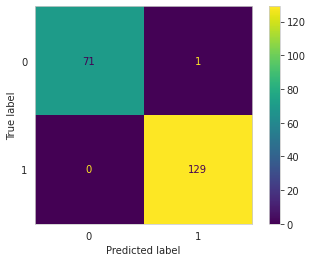

```python
plt.Figure(figsize=(10,6))
plot_confusion_matrix(estimator=model, X=X, y_true=y)
plt.grid()
plt.savefig(f'confusion_matrix.png')
```

```python
correct_classified = sum(model.predict(X) == y)
all_classified = len(y)
missclassified = all_classified - correct_classified
md('There are <b>{}</b> missclassifications on a total of <b>{}</b> observations'.format(missclassified, all_classified))
```

There are **1** missclassifications on a total of **201** observations

```python
print(classification_report(y, y_pred))
```

```
              precision    recall  f1-score   support

           0       1.00      0.99      0.99        72
           1       0.99      1.00      1.00       129

    accuracy                           1.00       201
   macro avg       1.00      0.99      0.99       201
weighted avg       1.00      1.00      1.00       201
```

### Feature Importance

This section tries to highlight the most important features in the dataset. Two approaches are chosen:

1. **regression coefficients** (only possible in regression models as LogisticRegression)
2. Feature importance with **SequentialFeatureSelection**

```python
position_estimator = [idx for idx, i in enumerate(list(model.best_estimator_.named_steps)) if i == 'estimator'][0]
best_estimator = model.best_estimator_.steps.pop(position_estimator)[1]
preprocessed_x = model.best_estimator_.fit_transform(X)
```

```python
if isinstance(preprocessed_x, pd.DataFrame):
    cols = preprocessed_x.columns
else:
    cols = X.columns
```

```python
if best_algorithm_name == 'LogisticRegression':
    coefs = pd.Series(index=cols, data=best_estimator.coef_[0])
    coefs = coefs.sort_values(ascending=False)
    coefs_abs = abs(coefs).sort_values(ascending=False)
    print(coefs)

    # build plot
    plt.figure(figsize=(10,4), dpi=100)
    ax = sns.barplot(x=coefs_abs.index, y=coefs_abs.values)
    for item in ax.get_xticklabels():
        item.set_rotation(75)
    fig = ax.get_figure()
    fig.savefig(f'feature_importance.png')

    md("The most important features seems to be <b>{}</b>".format(coefs[0:7].index.to_list()))
```

A second approach for the feature importance is the sequential feature selection (SFS).

SFS does not work with a pipeline object, therefore the estimator will be removed, data will be preprocessed with pipe without estimator and this estimator is given to SFS.

```python
if re_calculate is False and os.path.isfile('feature_importance.joblib'):
    feature_importance = joblib.load('feature_importance.joblib')
    sfs = joblib.load('sfs.joblib')
else:
    sfs = SFS(best_estimator,
               k_features=no_features,
               forward=True,
               scoring='accuracy',
               cv=5,
               n_jobs=-1)
    sfs = sfs.fit(preprocessed_x, y, custom_feature_names=cols.to_list())
    feature_importance = pd.DataFrame.from_dict(sfs.get_metric_dict()).T
    joblib.dump(feature_importance, 'feature_importance.joblib')
    joblib.dump(sfs, 'sfs.joblib')

feature_importance
```

|  | feature_idx | cv_scores | avg_score | feature_names | ci_bound | std_dev | std_err |
| --- | --- | --- | --- | --- | --- | --- | --- |
| 1 | (84,) | [0.6829268292682927, 0.775, 0.725, 0.8, 0.825] | 0.761585 | (crp_bb,) | 0.0660462 | 0.0513862 | 0.0256931 |
| 2 | (0, 84) | [0.7804878048780488, 0.85, 0.8, 0.875, 0.775] | 0.816098 | (age, crp_bb) | 0.0508789 | 0.0395855 | 0.0197928 |
| 3 | (0, 84, 93) | [0.8048780487804879, 0.85, 0.8, 0.8, 0.9] | 0.830976 | (age, crp_bb, wbc_aa) | 0.0505247 | 0.0393099 | 0.019655 |
| 4 | (0, 84, 93, 120) | [0.8048780487804879, 0.875, 0.85, 0.875, 0.925] | 0.865976 | (age, crp_bb, wbc_aa, respiratory_disease) | 0.0502248 | 0.0390766 | 0.0195383 |
| 5 | (0, 82, 84, 93, 120) | [0.8536585365853658, 0.875, 0.9, 0.875, 0.9] | 0.880732 | (age, crp_ab, crp_bb, wbc_aa, respiratory_dise... | 0.0225655 | 0.0175567 | 0.00877837 |
| 6 | (0, 49, 82, 84, 93, 120) | [0.8292682926829268, 0.9, 0.9, 0.9, 0.9] | 0.885854 | (age, d-dimer_aa, crp_ab, crp_bb, wbc_aa, resp... | 0.0363643 | 0.0282927 | 0.0141463 |
| 7 | (0, 49, 80, 82, 84, 93, 120) | [0.8536585365853658, 0.9, 0.9, 0.925, 0.925] | 0.900732 | (age, d-dimer_aa, ast_bb, crp_ab, crp_bb, wbc_... | 0.0334909 | 0.0260571 | 0.0130285 |
| 8 | (0, 22, 49, 80, 82, 84, 93, 120) | [0.8536585365853658, 0.9, 0.925, 0.925, 0.95] | 0.910732 | (age, troponin_ab, d-dimer_aa, ast_bb, crp_ab,... | 0.0419316 | 0.0326242 | 0.0163121 |
| 9 | (0, 3, 22, 49, 80, 82, 84, 93, 120) | [0.8536585365853658, 0.9, 0.925, 0.925, 0.95] | 0.910732 | (age, pltQlymphocytes_ba, troponin_ab, d-dimer... | 0.0419316 | 0.0326242 | 0.0163121 |
| 10 | (0, 3, 22, 23, 49, 80, 82, 84, 93, 120) | [0.8536585365853658, 0.9, 0.925, 0.925, 0.95] | 0.910732 | (age, pltQlymphocytes_ba, troponin_ab, troponi... | 0.0419316 | 0.0326242 | 0.0163121 |
| 11 | (0, 3, 22, 23, 26, 49, 80, 82, 84, 93, 120) | [0.8536585365853658, 0.9, 0.925, 0.925, 0.95] | 0.910732 | (age, pltQlymphocytes_ba, troponin_ab, troponi... | 0.0419316 | 0.0326242 | 0.0163121 |
| 12 | (0, 3, 22, 23, 26, 43, 49, 80, 82, 84, 93, 120) | [0.8536585365853658, 0.9, 0.925, 0.925, 0.95] | 0.910732 | (age, pltQlymphocytes_ba, troponin_ab, troponi... | 0.0419316 | 0.0326242 | 0.0163121 |
| 13 | (0, 3, 22, 23, 26, 43, 49, 63, 80, 82, 84, 93,... | [0.8536585365853658, 0.9, 0.925, 0.925, 0.95] | 0.910732 | (age, pltQlymphocytes_ba, troponin_ab, troponi... | 0.0419316 | 0.0326242 | 0.0163121 |
| 14 | (0, 3, 22, 23, 26, 43, 49, 63, 80, 82, 84, 87,... | [0.8536585365853658, 0.9, 0.925, 0.925, 0.925] | 0.905732 | (age, pltQlymphocytes_ba, troponin_ab, troponi... | 0.0357037 | 0.0277787 | 0.0138893 |
| 15 | (0, 3, 22, 23, 26, 43, 49, 56, 63, 80, 82, 84,... | [0.8536585365853658, 0.9, 0.925, 0.9, 0.95] | 0.905732 | (age, pltQlymphocytes_ba, troponin_ab, troponi... | 0.0410822 | 0.0319633 | 0.0159817 |

```python
def transform_feature_importance_to_list(feature_importance):
        feature_list = []
        for idx, item in enumerate(feature_importance['feature_names']):
            if idx == 0:
                feature_list.append(item[0])
            else:
                diff = [i for i in item if i not in feature_list]
                feature_list.append(diff[0])
        return feature_list
feature_importance_list = transform_feature_importance_to_list(feature_importance)
md("The most important features seems to be <br><br> <b>{}</b> <br><br> -> ordered by importance from important to less important!".format(feature_importance_list))
```

The most important features seems to be  
**['crp_bb', 'age', 'wbc_aa', 'respiratory_disease', 'crp_ab', 'd-dimer_aa', 'ast_bb', 'troponin_ab', 'pltQlymphocytes_ba', 'troponin_ba', 'hgb_ab', 'pt-s_ba', 'ck-mb_ba', 'pct_ba', 'alat_bb']**  
-> ordered by importance from important to less important!

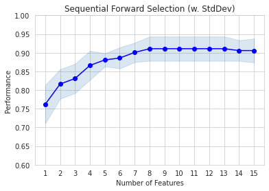

```python
plt.Figure(figsize=(10,6))
plot_sfs(sfs.get_metric_dict(), kind='std_dev')
plt.ylim([0.6,1.0])
plt.title('Sequential Forward Selection (w. StdDev)')
plt.savefig('sfs.png')
```

# Evaluate all (best) models (Feature Importance)

```python
no_features = 10
```

```python
if study_type == 'long':
    wf = f"{working_file}"
else:
    wf = f"{working_file}_adjusted"

evaluation = ModelEvaluation(working_file = f"{wf}.pkl",
                             target=target,
                             simulation_file='train_test_split_simulation.csv',
                             pipe='pipe.joblib')
```

```python
if re_calculate is False and os.path.isfile('overview_models.joblib'):
    overview_models = joblib.load('overview_models.joblib')
else:
    overview_models = evaluation.analyze_models(test_size=test_size, no_features=no_features)
    joblib.dump(overview_models, 'overview_models.joblib')
```

```python
pprint(overview_models)
```

```
[{'1_name': 'LogisticRegression',
  '2_best_param': {'estimator__C': 1,
                   'estimator__penalty': 'l2',
                   'prep__cat_pipeline__imputer_cat__n_neighbors': 3,
                   'prep__num_pipeline__imputer_num__n_neighbors': 1},
  '3_stats':       mean_cv_accuracy  mean_train_accuracy  test_accuracy
mean          0.855556             0.974222       0.845752
std           0.017578             0.028784       0.037692,
  '4_features': ['crp_bb',
                 'pct_ab',
                 'pltQneu_ab',
                 'creatinine_bb',
                 'hypertension',
                 'crp_aa',
                 'ast_aa',
                 'nephro',
                 'pdw_aa',
                 'pltQlymphocytes_ab']},
 {'1_name': 'KNeighborsClassifier',
  '2_best_param': {'estimator__n_neighbors': 3,
                   'estimator__weights': 'uniform',
                   'prep__cat_pipeline__imputer_cat__n_neighbors': 3,
                   'prep__num_pipeline__imputer_num__n_neighbors': 1},
  '3_stats':       mean_cv_accuracy  mean_train_accuracy  test_accuracy
mean          0.811556             0.865778       0.798693
std           0.022603             0.040556       0.056668,
  '4_features': ['wbc_aa',
                 'age',
                 'anti-platelets',
                 'cancer',
                 'mpv_ba',
                 'pltQlymphocytes_ab',
                 'ast_ab',
                 'alat_ba',
                 'pdw_ba',
                 'alat_bb']},
 {'1_name': 'RandomForestClassifier',
  '2_best_param': {'estimator__max_depth': 3,
                   'estimator__min_samples_leaf': 0.01,
                   'estimator__min_samples_split': 0.001,
```

[output cut: 75 more lines]

```
                   'prep__cat_pipeline__imputer_cat__n_neighbors': 1,
                   'prep__num_pipeline__imputer_num__n_neighbors': 3},
  '3_stats':       mean_cv_accuracy  mean_train_accuracy  test_accuracy
mean          0.860889             0.946667       0.807843
std           0.020294             0.021958       0.065954,
  '4_features': ['crp_bb',
                 'age',
                 'creatinine_bb',
                 'crp_ab',
                 'monQlymphocytes_ab',
                 'creatinine_ab',
                 'pltQlymphocytes_aa',
                 'aptt_bb',
                 'monQlymphocytes_bb',
                 'd-dimer_aa']}]
```

```python
%%javascript
IPython.notebook.save_notebook()
```

```python
# store this notebook as html in specific folder
os.system(f'jupyter nbconvert --to html final_evaluation.ipynb')
```

```
0
```

# Final Feature Importance

To calculate the final feature importance th 10 best features of every (best) algorithm is taken. These features got rank 1 to 10 (and 11 for all not used features). The median rank of all 7 algorithms givs the final feature importance:

```python
overview_models = joblib.load('overview_models.joblib')
```

```python
# giving rank points
rank_list = []
for model in overview_models:
    rank = {}
    for idx, item in enumerate(model['4_features']):
        rank.update({item: [idx+1]})
    rank_list.append(rank)
pprint(rank_list)
```

```
[{'ast_aa': [7],
  'creatinine_bb': [4],
  'crp_aa': [6],
  'crp_bb': [1],
  'hypertension': [5],
  'nephro': [8],
  'pct_ab': [2],
  'pdw_aa': [9],
  'pltQlymphocytes_ab': [10],
  'pltQneu_ab': [3]},
 {'age': [2],
  'alat_ba': [8],
  'alat_bb': [10],
  'anti-platelets': [3],
  'ast_ab': [7],
  'cancer': [4],
  'mpv_ba': [5],
  'pdw_ba': [9],
  'pltQlymphocytes_ab': [6],
  'wbc_aa': [1]},
 {'age': [2],
  'antibody-lympho_ab': [10],
  'basoQlymphocytes_bb': [6],
  'crp_aa': [7],
  'crp_bb': [1],
  'd-dimer_aa': [9],
  'hypertension': [8],
  'pct_aa': [5],
  'troponin_aa': [4],
  'wbc_aa': [3]},
 {'age': [2],
  'crp_bb': [1],
  'd-dimer_aa': [9],
  'hypertension': [6],
  'monQlymphocytes_ab': [7],
  'neuQlymphocytes_bb': [8],
  'pct_aa': [4],
  'pltQlymphocytes_bb': [10],
  'wbc_aa': [3],
  'wbc_bb': [5]},
```

[output cut: 15 more lines]

```
  'pct_ba': [6],
  'pltQlymphocytes_ab': [9],
  'pltQlymphocytes_ba': [10],
  'pltQneu_ab': [7],
  'wbc_aa': [4]},
 {'age': [2],
  'aptt_bb': [8],
  'creatinine_ab': [6],
  'creatinine_bb': [3],
  'crp_ab': [4],
  'crp_bb': [1],
  'd-dimer_aa': [10],
  'monQlymphocytes_ab': [5],
  'monQlymphocytes_bb': [9],
  'pltQlymphocytes_aa': [7]}]
```

```python
# combining all dictionaries
def combine_dict(dict1,dict2):
    dict3 = {}
    for key in set().union(dict1, dict2):
        if key in dict1: dict3.setdefault(key, []).extend(dict1[key])
        if key in dict2: dict3.setdefault(key, []).extend(dict2[key])
    return dict3

combined_dict = functools.reduce(lambda a,b : combine_dict(a,b) ,rank_list)
print(combined_dict)
```

```
{'creatinine_bb': [4, 3], 'crp_ab': [5, 4], 'antibody-lympho_ab': [10], 'pltQlymphocytes_ba': [9, 10], 'antibody-lympho_ba': [3], 'mpv_bb': [8], 'ast_ab': [7], 'alat_bb': [10], 'ldh_aa': [5], 'troponin_ba': [10], 'pct_ab': [2], 'd-dimer_aa': [9, 9, 6, 10], 'troponin_ab': [8], 'alat_ba': [8], 'anti-p…
```

```python
# extend dictionaries with 11 until length of number of algorithms is reached (7)
extended_dict = {}
for k,v in combined_dict.items():
    l = v + [11]*(7-len(v))
    extended_dict.update({k: l})
print(extended_dict)
```

```
{'creatinine_bb': [4, 3, 11, 11, 11, 11, 11], 'crp_ab': [5, 4, 11, 11, 11, 11, 11], 'antibody-lympho_ab': [10, 11, 11, 11, 11, 11, 11], 'pltQlymphocytes_ba': [9, 10, 11, 11, 11, 11, 11], 'antibody-lympho_ba': [3, 11, 11, 11, 11, 11, 11], 'mpv_bb': [8, 11, 11, 11, 11, 11, 11], 'ast_ab': [7, 11, 11, 1…
```

```python
# calculate median of each item
median = {}
for k,v in extended_dict.items():
    median.update({k: statistics.median(v)})
print(median)
```

```
{'creatinine_bb': 11, 'crp_ab': 11, 'antibody-lympho_ab': 11, 'pltQlymphocytes_ba': 11, 'antibody-lympho_ba': 11, 'mpv_bb': 11, 'ast_ab': 11, 'alat_bb': 11, 'ldh_aa': 11, 'troponin_ba': 11, 'pct_ab': 11, 'd-dimer_aa': 10, 'troponin_ab': 11, 'alat_ba': 11, 'anti-platelets': 11, 'monQlymphocytes_ab': …
```

```python
# sorting items with values
{k: v for k, v in sorted(median.items(), key=lambda item: item[1])}
```

```
{'crp_bb': 1,
 'age': 2,
 'wbc_aa': 3,
 'd-dimer_aa': 10,
 'creatinine_bb': 11,
 'crp_ab': 11,
 'antibody-lympho_ab': 11,
 'pltQlymphocytes_ba': 11,
 'antibody-lympho_ba': 11,
 'mpv_bb': 11,
 'ast_ab': 11,
 'alat_bb': 11,
 'ldh_aa': 11,
 'troponin_ba': 11,
 'pct_ab': 11,
 'troponin_ab': 11,
 'alat_ba': 11,
 'anti-platelets': 11,
 'monQlymphocytes_ab': 11,
 'monQlymphocytes_bb': 11,
 'wbc_bb': 11,
 'creatinine_ab': 11,
 'pdw_aa': 11,
 'ast_bb': 11,
 'crp_aa': 11,
 'respiratory_disease': 11,
 'basoQlymphocytes_bb': 11,
 'pltQlymphocytes_bb': 11,
 'nephro': 11,
 'pltQneu_ab': 11,
 'cancer': 11,
 'neuQlymphocytes_bb': 11,
 'pct_ba': 11,
 'mpv_ba': 11,
 'pdw_ba': 11,
 'ast_aa': 11,
 'aptt_bb': 11,
 'hypertension': 11,
 'troponin_aa': 11,
 'pltQlymphocytes_aa': 11,
 'pct_aa': 11,
 'pltQlymphocytes_ab': 11}
```